# Risk Factor Analysis

## Outcome Variable

**Outcome Variable:** wasted

## Predictor Variables

**Intervention Variable:** mbmi

**Adjustment Set:**

- arm
- W_mage
- meducyrs
- feducyrs
- single
- brthmon
- W_parity
- delta_W_mage
- delta_meducyrs
- delta_feducyrs
- delta_single
- delta_brthmon
- delta_W_parity

## Stratifying Variables

The analysis was stratified on these variable(s):

- agecat
- studyid
- country

## Data Summary

| agecat | studyid | country | mbmi | wasted | n_cell | n |
| --- | --- | --- | --- | --- | --- | --- |
| Birth | JiVitA-3 | BANGLADESH | Normal weight | 0 | 9723 | 17935 |
| Birth | JiVitA-3 | BANGLADESH | Normal weight | 1 | 1211 | 17935 |
| Birth | JiVitA-3 | BANGLADESH | Underweight | 0 | 6244 | 17935 |
| Birth | JiVitA-3 | BANGLADESH | Underweight | 1 | 757 | 17935 |
| Birth | MAL-ED | BANGLADESH | Normal weight | 0 | 154 | 209 |
| Birth | MAL-ED | BANGLADESH | Normal weight | 1 | 29 | 209 |
| Birth | MAL-ED | BANGLADESH | Underweight | 0 | 20 | 209 |
| Birth | MAL-ED | BANGLADESH | Underweight | 1 | 6 | 209 |
| Birth | MAL-ED | BRAZIL | Normal weight | 0 | 55 | 61 |
| Birth | MAL-ED | BRAZIL | Normal weight | 1 | 1 | 61 |
| Birth | MAL-ED | BRAZIL | Underweight | 0 | 4 | 61 |
| Birth | MAL-ED | BRAZIL | Underweight | 1 | 1 | 61 |
| Birth | MAL-ED | INDIA | Normal weight | 0 | 29 | 41 |
| Birth | MAL-ED | INDIA | Normal weight | 1 | 4 | 41 |
| Birth | MAL-ED | INDIA | Underweight | 0 | 7 | 41 |
| Birth | MAL-ED | INDIA | Underweight | 1 | 1 | 41 |
| Birth | MAL-ED | NEPAL | Normal weight | 0 | 24 | 26 |
| Birth | MAL-ED | NEPAL | Normal weight | 1 | 2 | 26 |
| Birth | MAL-ED | NEPAL | Underweight | 0 | 0 | 26 |
| Birth | MAL-ED | NEPAL | Underweight | 1 | 0 | 26 |
| Birth | MAL-ED | PERU | Normal weight | 0 | 211 | 221 |
| Birth | MAL-ED | PERU | Normal weight | 1 | 5 | 221 |
| Birth | MAL-ED | PERU | Underweight | 0 | 5 | 221 |
| Birth | MAL-ED | PERU | Underweight | 1 | 0 | 221 |
| Birth | MAL-ED | SOUTH AFRICA | Normal weight | 0 | 87 | 100 |
| Birth | MAL-ED | SOUTH AFRICA | Normal weight | 1 | 10 | 100 |
| Birth | MAL-ED | SOUTH AFRICA | Underweight | 0 | 3 | 100 |
| Birth | MAL-ED | SOUTH AFRICA | Underweight | 1 | 0 | 100 |
| Birth | MAL-ED | TANZANIA, UNITED REPUBLIC OF | Normal weight | 0 | 106 | 113 |
| Birth | MAL-ED | TANZANIA, UNITED REPUBLIC OF | Normal weight | 1 | 1 | 113 |

[output cut: 150 more lines]

The following strata were considered:

- agecat: 24 months, studyid: JiVitA-3, country: BANGLADESH
- agecat: 24 months, studyid: LCNI-5, country: MALAWI
- agecat: 24 months, studyid: MAL-ED, country: BANGLADESH
- agecat: 24 months, studyid: MAL-ED, country: BRAZIL
- agecat: 24 months, studyid: MAL-ED, country: INDIA
- agecat: 24 months, studyid: MAL-ED, country: NEPAL
- agecat: 24 months, studyid: MAL-ED, country: PERU
- agecat: 24 months, studyid: MAL-ED, country: SOUTH AFRICA
- agecat: 24 months, studyid: MAL-ED, country: TANZANIA, UNITED REPUBLIC OF
- agecat: 24 months, studyid: NIH-Birth, country: BANGLADESH
- agecat: 24 months, studyid: NIH-Crypto, country: BANGLADESH
- agecat: 24 months, studyid: PROBIT, country: BELARUS
- agecat: 24 months, studyid: PROVIDE, country: BANGLADESH
- agecat: 24 months, studyid: TanzaniaChild2, country: TANZANIA, UNITED REPUBLIC OF
- agecat: 24 months, studyid: ZVITAMBO, country: ZIMBABWE
- agecat: 6 months, studyid: JiVitA-3, country: BANGLADESH
- agecat: 6 months, studyid: LCNI-5, country: MALAWI
- agecat: 6 months, studyid: MAL-ED, country: BANGLADESH
- agecat: 6 months, studyid: MAL-ED, country: BRAZIL
- agecat: 6 months, studyid: MAL-ED, country: INDIA
- agecat: 6 months, studyid: MAL-ED, country: NEPAL
- agecat: 6 months, studyid: MAL-ED, country: PERU
- agecat: 6 months, studyid: MAL-ED, country: SOUTH AFRICA
- agecat: 6 months, studyid: MAL-ED, country: TANZANIA, UNITED REPUBLIC OF
- agecat: 6 months, studyid: NIH-Birth, country: BANGLADESH
- agecat: 6 months, studyid: NIH-Crypto, country: BANGLADESH
- agecat: 6 months, studyid: PROBIT, country: BELARUS
- agecat: 6 months, studyid: PROVIDE, country: BANGLADESH
- agecat: 6 months, studyid: SAS-CompFeed, country: INDIA
- agecat: 6 months, studyid: TanzaniaChild2, country: TANZANIA, UNITED REPUBLIC OF
- agecat: 6 months, studyid: ZVITAMBO, country: ZIMBABWE
- agecat: Birth, studyid: JiVitA-3, country: BANGLADESH
- agecat: Birth, studyid: MAL-ED, country: BANGLADESH
- agecat: Birth, studyid: MAL-ED, country: BRAZIL
- agecat: Birth, studyid: MAL-ED, country: INDIA
- agecat: Birth, studyid: MAL-ED, country: NEPAL
- agecat: Birth, studyid: MAL-ED, country: PERU
- agecat: Birth, studyid: MAL-ED, country: SOUTH AFRICA
- agecat: Birth, studyid: MAL-ED, country: TANZANIA, UNITED REPUBLIC OF
- agecat: Birth, studyid: NIH-Birth, country: BANGLADESH
- agecat: Birth, studyid: NIH-Crypto, country: BANGLADESH
- agecat: Birth, studyid: PROBIT, country: BELARUS
- agecat: Birth, studyid: PROVIDE, country: BANGLADESH
- agecat: Birth, studyid: SAS-CompFeed, country: INDIA
- agecat: Birth, studyid: ZVITAMBO, country: ZIMBABWE

### Dropped Strata

Some strata were dropped due to rare outcomes:

- agecat: Birth, studyid: MAL-ED, country: BRAZIL
- agecat: Birth, studyid: MAL-ED, country: INDIA
- agecat: Birth, studyid: MAL-ED, country: NEPAL
- agecat: Birth, studyid: MAL-ED, country: PERU
- agecat: Birth, studyid: MAL-ED, country: SOUTH AFRICA
- agecat: Birth, studyid: MAL-ED, country: TANZANIA, UNITED REPUBLIC OF
- agecat: 6 months, studyid: LCNI-5, country: MALAWI
- agecat: 6 months, studyid: MAL-ED, country: BANGLADESH
- agecat: 6 months, studyid: MAL-ED, country: BRAZIL
- agecat: 6 months, studyid: MAL-ED, country: NEPAL
- agecat: 6 months, studyid: MAL-ED, country: PERU
- agecat: 6 months, studyid: MAL-ED, country: SOUTH AFRICA
- agecat: 6 months, studyid: MAL-ED, country: TANZANIA, UNITED REPUBLIC OF
- agecat: 6 months, studyid: PROBIT, country: BELARUS
- agecat: 6 months, studyid: TanzaniaChild2, country: TANZANIA, UNITED REPUBLIC OF
- agecat: 24 months, studyid: MAL-ED, country: BRAZIL
- agecat: 24 months, studyid: MAL-ED, country: NEPAL
- agecat: 24 months, studyid: MAL-ED, country: PERU
- agecat: 24 months, studyid: MAL-ED, country: SOUTH AFRICA
- agecat: 24 months, studyid: MAL-ED, country: TANZANIA, UNITED REPUBLIC OF
- agecat: 24 months, studyid: NIH-Crypto, country: BANGLADESH
- agecat: 24 months, studyid: PROBIT, country: BELARUS
- agecat: 24 months, studyid: TanzaniaChild2, country: TANZANIA, UNITED REPUBLIC OF

## Methods Detail

We’re interested in the causal parameters $E[Y_a]$ for all values of $a \in \mathcal{A}$. These parameters represent the mean outcome if, possibly contrary to fact, we intervened to set all units to have $A=a$. Under the randomization and positivity assumptions, these are identified by the statistical parameters $\psi_a=E_W[E_{Y|A,W}(Y|A=a,W)]$. In addition, we’re interested in the mean of $Y$, $E[Y]$ under no intervention (the observed mean). We will estimate these parameters by using SuperLearner to fit the relevant likelihood factors – $E_{Y|A,W}(Y|A=a,W)$ and $p(A=a|W)$, and then updating our likelihood fit using a joint TMLE.

For unadjusted analyses ($W=\{\}$), initial likelihoods were estimated using Lrnr_glm to estimate the simple $E(Y|A)$ and Lrnr_mean to estimate $p(A)$. For adjusted analyses, a small library containing Lrnr_glmnet, Lrnr_xgboost, and Lrnr_mean was used.

Having estimated these parameters, we will then use the delta method to estimate relative risks and attributable risks relative to a prespecified baseline level of $A$.

# Results Detail

## Results Plots

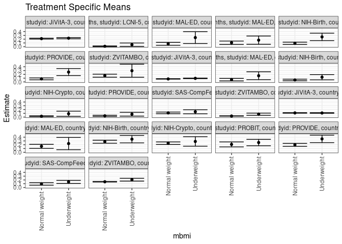

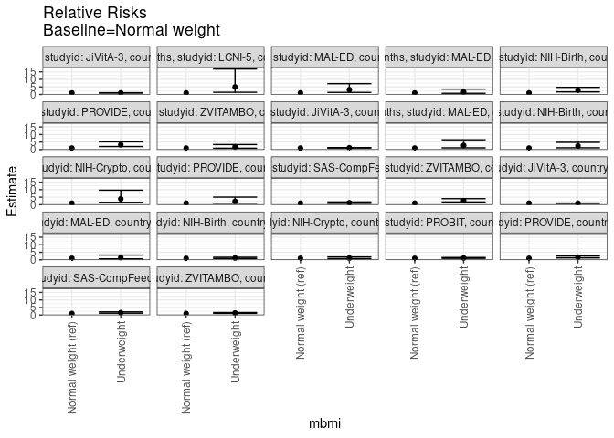

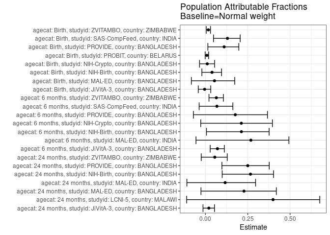

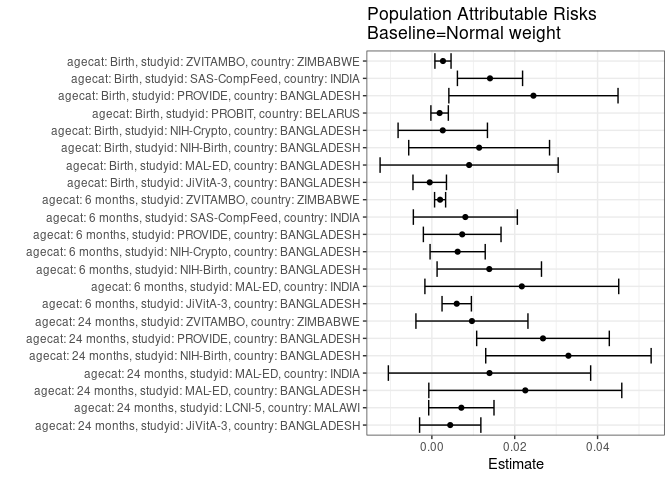

## Results Table

### Parameter: TSM

| agecat | studyid | country | intervention_level | baseline_level | estimate | ci_lower | ci_upper |
| --- | --- | --- | --- | --- | --- | --- | --- |
| Birth | JiVitA-3 | BANGLADESH | Normal weight | NA | 0.1102478 | 0.1035292 | 0.1169664 |
| Birth | JiVitA-3 | BANGLADESH | Underweight | NA | 0.1088094 | 0.1007985 | 0.1168204 |
| Birth | MAL-ED | BANGLADESH | Normal weight | NA | 0.1584699 | 0.1054338 | 0.2115061 |
| Birth | MAL-ED | BANGLADESH | Underweight | NA | 0.2307692 | 0.0684312 | 0.3931072 |
| Birth | NIH-Birth | BANGLADESH | Normal weight | NA | 0.2807650 | 0.2407395 | 0.3207904 |
| Birth | NIH-Birth | BANGLADESH | Underweight | NA | 0.3470021 | 0.2487590 | 0.4452451 |
| Birth | NIH-Crypto | BANGLADESH | Normal weight | NA | 0.2402665 | 0.2069971 | 0.2735360 |
| Birth | NIH-Crypto | BANGLADESH | Underweight | NA | 0.2870132 | 0.1615476 | 0.4124787 |
| Birth | PROBIT | BELARUS | Normal weight | NA | 0.2084435 | 0.1431449 | 0.2737422 |
| Birth | PROBIT | BELARUS | Underweight | NA | 0.2579860 | 0.1734724 | 0.3424995 |
| Birth | PROVIDE | BANGLADESH | Normal weight | NA | 0.1970502 | 0.1583596 | 0.2357408 |
| Birth | PROVIDE | BANGLADESH | Underweight | NA | 0.3539019 | 0.2549266 | 0.4528772 |
| Birth | SAS-CompFeed | INDIA | Normal weight | NA | 0.0938311 | 0.0609286 | 0.1267336 |
| Birth | SAS-CompFeed | INDIA | Underweight | NA | 0.1481610 | 0.1070817 | 0.1892403 |
| Birth | ZVITAMBO | ZIMBABWE | Normal weight | NA | 0.1516916 | 0.1440966 | 0.1592866 |
| Birth | ZVITAMBO | ZIMBABWE | Underweight | NA | 0.2065796 | 0.1689969 | 0.2441622 |
| 6 months | JiVitA-3 | BANGLADESH | Normal weight | NA | 0.0785641 | 0.0728342 | 0.0842939 |
| 6 months | JiVitA-3 | BANGLADESH | Underweight | NA | 0.0940546 | 0.0863051 | 0.1018041 |
| 6 months | MAL-ED | INDIA | Normal weight | NA | 0.0591398 | 0.0251679 | 0.0931117 |
| 6 months | MAL-ED | INDIA | Underweight | NA | 0.1632653 | 0.0595562 | 0.2669744 |
| 6 months | NIH-Birth | BANGLADESH | Normal weight | NA | 0.0513178 | 0.0306451 | 0.0719906 |
| 6 months | NIH-Birth | BANGLADESH | Underweight | NA | 0.1246036 | 0.0550471 | 0.1941602 |
| 6 months | NIH-Crypto | BANGLADESH | Normal weight | NA | 0.0231481 | 0.0115621 | 0.0347342 |
| 6 months | NIH-Crypto | BANGLADESH | Underweight | NA | 0.0895522 | 0.0211327 | 0.1579718 |
| 6 months | PROVIDE | BANGLADESH | Normal weight | NA | 0.0342052 | 0.0182126 | 0.0501979 |
| 6 months | PROVIDE | BANGLADESH | Underweight | NA | 0.0761905 | 0.0254031 | 0.1269779 |
| 6 months | SAS-CompFeed | INDIA | Normal weight | NA | 0.1110032 | 0.0896351 | 0.1323714 |
| 6 months | SAS-CompFeed | INDIA | Underweight | NA | 0.1409582 | 0.0875581 | 0.1943584 |
| 6 months | ZVITAMBO | ZIMBABWE | Normal weight | NA | 0.0287595 | 0.0248078 | 0.0327112 |
| 6 months | ZVITAMBO | ZIMBABWE | Underweight | NA | 0.0773540 | 0.0487055 | 0.1060026 |
| 24 months | JiVitA-3 | BANGLADESH | Normal weight | NA | 0.2135368 | 0.2018210 | 0.2252527 |
| 24 months | JiVitA-3 | BANGLADESH | Underweight | NA | 0.2253372 | 0.2091488 | 0.2415255 |
| 24 months | LCNI-5 | MALAWI | Normal weight | NA | 0.0107066 | 0.0013641 | 0.0200492 |
| 24 months | LCNI-5 | MALAWI | Underweight | NA | 0.0531915 | 0.0077844 | 0.0985986 |
| 24 months | MAL-ED | BANGLADESH | Normal weight | NA | 0.0765027 | 0.0379011 | 0.1151044 |
| 24 months | MAL-ED | BANGLADESH | Underweight | NA | 0.2413793 | 0.0852666 | 0.3974920 |
| 24 months | MAL-ED | INDIA | Normal weight | NA | 0.1055556 | 0.0605680 | 0.1505431 |
| 24 months | MAL-ED | INDIA | Underweight | NA | 0.1739130 | 0.0641361 | 0.2836900 |
| 24 months | NIH-Birth | BANGLADESH | Normal weight | NA | 0.0908680 | 0.0604792 | 0.1212569 |
| 24 months | NIH-Birth | BANGLADESH | Underweight | NA | 0.2596663 | 0.1615229 | 0.3578097 |
| 24 months | PROVIDE | BANGLADESH | Normal weight | NA | 0.0804437 | 0.0560090 | 0.1048784 |
| 24 months | PROVIDE | BANGLADESH | Underweight | NA | 0.2603417 | 0.1680484 | 0.3526349 |
| 24 months | ZVITAMBO | ZIMBABWE | Normal weight | NA | 0.1651917 | 0.1256068 | 0.2047767 |
| 24 months | ZVITAMBO | ZIMBABWE | Underweight | NA | 0.2962963 | 0.1238244 | 0.4687682 |

### Parameter: E(Y)

| agecat | studyid | country | intervention_level | baseline_level | estimate | ci_lower | ci_upper |
| --- | --- | --- | --- | --- | --- | --- | --- |
| Birth | JiVitA-3 | BANGLADESH | NA | NA | 0.1097296 | 0.1045905 | 0.1148686 |
| Birth | MAL-ED | BANGLADESH | NA | NA | 0.1674641 | 0.1167208 | 0.2182074 |
| Birth | NIH-Birth | BANGLADESH | NA | NA | 0.2921739 | 0.2549711 | 0.3293768 |
| Birth | NIH-Crypto | BANGLADESH | NA | NA | 0.2428977 | 0.2111977 | 0.2745977 |
| Birth | PROBIT | BELARUS | NA | NA | 0.2103143 | 0.1449220 | 0.2757065 |
| Birth | PROVIDE | BANGLADESH | NA | NA | 0.2215686 | 0.1854897 | 0.2576475 |
| Birth | SAS-CompFeed | INDIA | NA | NA | 0.1078629 | 0.0749278 | 0.1407980 |
| Birth | ZVITAMBO | ZIMBABWE | NA | NA | 0.1543743 | 0.1469218 | 0.1618269 |
| 6 months | JiVitA-3 | BANGLADESH | NA | NA | 0.0845634 | 0.0797479 | 0.0893790 |
| 6 months | MAL-ED | INDIA | NA | NA | 0.0808511 | 0.0459229 | 0.1157792 |
| 6 months | NIH-Birth | BANGLADESH | NA | NA | 0.0651769 | 0.0442802 | 0.0860736 |
| 6 months | NIH-Crypto | BANGLADESH | NA | NA | 0.0293706 | 0.0169860 | 0.0417552 |
| 6 months | PROVIDE | BANGLADESH | NA | NA | 0.0415282 | 0.0255778 | 0.0574787 |
| 6 months | SAS-CompFeed | INDIA | NA | NA | 0.1190865 | 0.0945854 | 0.1435876 |
| 6 months | ZVITAMBO | ZIMBABWE | NA | NA | 0.0307459 | 0.0267728 | 0.0347190 |
| 24 months | JiVitA-3 | BANGLADESH | NA | NA | 0.2179697 | 0.2080911 | 0.2278482 |
| 24 months | LCNI-5 | MALAWI | NA | NA | 0.0178253 | 0.0068664 | 0.0287842 |
| 24 months | MAL-ED | BANGLADESH | NA | NA | 0.0990566 | 0.0587480 | 0.1393652 |
| 24 months | MAL-ED | INDIA | NA | NA | 0.1194690 | 0.0770894 | 0.1618486 |
| 24 months | NIH-Birth | BANGLADESH | NA | NA | 0.1238318 | 0.0925894 | 0.1550741 |
| 24 months | PROVIDE | BANGLADESH | NA | NA | 0.1072664 | 0.0820169 | 0.1325160 |
| 24 months | ZVITAMBO | ZIMBABWE | NA | NA | 0.1748634 | 0.1358949 | 0.2138319 |

### Parameter: RR

| agecat | studyid | country | intervention_level | baseline_level | estimate | ci_lower | ci_upper |
| --- | --- | --- | --- | --- | --- | --- | --- |
| Birth | JiVitA-3 | BANGLADESH | Normal weight | Normal weight | 1.0000000 | 1.0000000 | 1.000000 |
| Birth | JiVitA-3 | BANGLADESH | Underweight | Normal weight | 0.9869537 | 0.8973986 | 1.085446 |
| Birth | MAL-ED | BANGLADESH | Normal weight | Normal weight | 1.0000000 | 1.0000000 | 1.000000 |
| Birth | MAL-ED | BANGLADESH | Underweight | Normal weight | 1.4562334 | 0.6682012 | 3.173619 |
| Birth | NIH-Birth | BANGLADESH | Normal weight | Normal weight | 1.0000000 | 1.0000000 | 1.000000 |
| Birth | NIH-Birth | BANGLADESH | Underweight | Normal weight | 1.2359166 | 0.9007988 | 1.695706 |
| Birth | NIH-Crypto | BANGLADESH | Normal weight | Normal weight | 1.0000000 | 1.0000000 | 1.000000 |
| Birth | NIH-Crypto | BANGLADESH | Underweight | Normal weight | 1.1945616 | 0.7547911 | 1.890559 |
| Birth | PROBIT | BELARUS | Normal weight | Normal weight | 1.0000000 | 1.0000000 | 1.000000 |
| Birth | PROBIT | BELARUS | Underweight | Normal weight | 1.2376780 | 1.0032719 | 1.526851 |
| Birth | PROVIDE | BANGLADESH | Normal weight | Normal weight | 1.0000000 | 1.0000000 | 1.000000 |
| Birth | PROVIDE | BANGLADESH | Underweight | Normal weight | 1.7959984 | 1.2775728 | 2.524796 |
| Birth | SAS-CompFeed | INDIA | Normal weight | Normal weight | 1.0000000 | 1.0000000 | 1.000000 |
| Birth | SAS-CompFeed | INDIA | Underweight | Normal weight | 1.5790177 | 1.1993701 | 2.078839 |
| Birth | ZVITAMBO | ZIMBABWE | Normal weight | Normal weight | 1.0000000 | 1.0000000 | 1.000000 |
| Birth | ZVITAMBO | ZIMBABWE | Underweight | Normal weight | 1.3618392 | 1.1276744 | 1.644629 |
| 6 months | JiVitA-3 | BANGLADESH | Normal weight | Normal weight | 1.0000000 | 1.0000000 | 1.000000 |
| 6 months | JiVitA-3 | BANGLADESH | Underweight | Normal weight | 1.1971706 | 1.0783634 | 1.329067 |
| 6 months | MAL-ED | INDIA | Normal weight | Normal weight | 1.0000000 | 1.0000000 | 1.000000 |
| 6 months | MAL-ED | INDIA | Underweight | Normal weight | 2.7606679 | 1.1723848 | 6.500671 |
| 6 months | NIH-Birth | BANGLADESH | Normal weight | Normal weight | 1.0000000 | 1.0000000 | 1.000000 |
| 6 months | NIH-Birth | BANGLADESH | Underweight | Normal weight | 2.4280770 | 1.2188415 | 4.837018 |
| 6 months | NIH-Crypto | BANGLADESH | Normal weight | Normal weight | 1.0000000 | 1.0000000 | 1.000000 |
| 6 months | NIH-Crypto | BANGLADESH | Underweight | Normal weight | 3.8686567 | 1.5519898 | 9.643430 |
| 6 months | PROVIDE | BANGLADESH | Normal weight | Normal weight | 1.0000000 | 1.0000000 | 1.000000 |
| 6 months | PROVIDE | BANGLADESH | Underweight | Normal weight | 2.2274510 | 0.9867371 | 5.028227 |
| 6 months | SAS-CompFeed | INDIA | Normal weight | Normal weight | 1.0000000 | 1.0000000 | 1.000000 |
| 6 months | SAS-CompFeed | INDIA | Underweight | Normal weight | 1.2698572 | 0.8915332 | 1.808724 |
| 6 months | ZVITAMBO | ZIMBABWE | Normal weight | Normal weight | 1.0000000 | 1.0000000 | 1.000000 |
| 6 months | ZVITAMBO | ZIMBABWE | Underweight | Normal weight | 2.6896898 | 1.8121470 | 3.992188 |
| 24 months | JiVitA-3 | BANGLADESH | Normal weight | Normal weight | 1.0000000 | 1.0000000 | 1.000000 |
| 24 months | JiVitA-3 | BANGLADESH | Underweight | Normal weight | 1.0552613 | 0.9674264 | 1.151071 |
| 24 months | LCNI-5 | MALAWI | Normal weight | Normal weight | 1.0000000 | 1.0000000 | 1.000000 |
| 24 months | LCNI-5 | MALAWI | Underweight | Normal weight | 4.9680851 | 1.4656789 | 16.839889 |
| 24 months | MAL-ED | BANGLADESH | Normal weight | Normal weight | 1.0000000 | 1.0000000 | 1.000000 |
| 24 months | MAL-ED | BANGLADESH | Underweight | Normal weight | 3.1551724 | 1.3892244 | 7.165950 |
| 24 months | MAL-ED | INDIA | Normal weight | Normal weight | 1.0000000 | 1.0000000 | 1.000000 |
| 24 months | MAL-ED | INDIA | Underweight | Normal weight | 1.6475973 | 0.7692713 | 3.528764 |
| 24 months | NIH-Birth | BANGLADESH | Normal weight | Normal weight | 1.0000000 | 1.0000000 | 1.000000 |
| 24 months | NIH-Birth | BANGLADESH | Underweight | Normal weight | 2.8576198 | 1.7262343 | 4.730523 |
| 24 months | PROVIDE | BANGLADESH | Normal weight | Normal weight | 1.0000000 | 1.0000000 | 1.000000 |
| 24 months | PROVIDE | BANGLADESH | Underweight | Normal weight | 3.2363227 | 2.0275894 | 5.165634 |
| 24 months | ZVITAMBO | ZIMBABWE | Normal weight | Normal weight | 1.0000000 | 1.0000000 | 1.000000 |
| 24 months | ZVITAMBO | ZIMBABWE | Underweight | Normal weight | 1.7936508 | 0.9557734 | 3.366052 |

### Parameter: PAR

| agecat | studyid | country | intervention_level | baseline_level | estimate | ci_lower | ci_upper |
| --- | --- | --- | --- | --- | --- | --- | --- |
| Birth | JiVitA-3 | BANGLADESH | Normal weight | NA | -0.0005182 | -0.0045592 | 0.0035228 |
| Birth | MAL-ED | BANGLADESH | Normal weight | NA | 0.0089942 | -0.0124975 | 0.0304858 |
| Birth | NIH-Birth | BANGLADESH | Normal weight | NA | 0.0114089 | -0.0055846 | 0.0284025 |
| Birth | NIH-Crypto | BANGLADESH | Normal weight | NA | 0.0026312 | -0.0081531 | 0.0134155 |
| Birth | PROBIT | BELARUS | Normal weight | NA | 0.0018707 | -0.0002341 | 0.0039755 |
| Birth | PROVIDE | BANGLADESH | Normal weight | NA | 0.0245184 | 0.0041016 | 0.0449352 |
| Birth | SAS-CompFeed | INDIA | Normal weight | NA | 0.0140318 | 0.0061676 | 0.0218959 |
| Birth | ZVITAMBO | ZIMBABWE | Normal weight | NA | 0.0026827 | 0.0007351 | 0.0046303 |
| 6 months | JiVitA-3 | BANGLADESH | Normal weight | NA | 0.0059994 | 0.0024564 | 0.0095423 |
| 6 months | MAL-ED | INDIA | Normal weight | NA | 0.0217113 | -0.0016803 | 0.0451029 |
| 6 months | NIH-Birth | BANGLADESH | Normal weight | NA | 0.0138591 | 0.0012605 | 0.0264577 |
| 6 months | NIH-Crypto | BANGLADESH | Normal weight | NA | 0.0062225 | -0.0004333 | 0.0128782 |
| 6 months | PROVIDE | BANGLADESH | Normal weight | NA | 0.0073230 | -0.0020510 | 0.0166970 |
| 6 months | SAS-CompFeed | INDIA | Normal weight | NA | 0.0080832 | -0.0044688 | 0.0206353 |
| 6 months | ZVITAMBO | ZIMBABWE | Normal weight | NA | 0.0019864 | 0.0006537 | 0.0033192 |
| 24 months | JiVitA-3 | BANGLADESH | Normal weight | NA | 0.0044328 | -0.0029606 | 0.0118263 |
| 24 months | LCNI-5 | MALAWI | Normal weight | NA | 0.0071187 | -0.0007594 | 0.0149967 |
| 24 months | MAL-ED | BANGLADESH | Normal weight | NA | 0.0225539 | -0.0007348 | 0.0458425 |
| 24 months | MAL-ED | INDIA | Normal weight | NA | 0.0139135 | -0.0105003 | 0.0383272 |
| 24 months | NIH-Birth | BANGLADESH | Normal weight | NA | 0.0329637 | 0.0130006 | 0.0529269 |
| 24 months | PROVIDE | BANGLADESH | Normal weight | NA | 0.0268228 | 0.0108166 | 0.0428290 |
| 24 months | ZVITAMBO | ZIMBABWE | Normal weight | NA | 0.0096716 | -0.0038477 | 0.0231909 |

### Parameter: PAF

| agecat | studyid | country | intervention_level | baseline_level | estimate | ci_lower | ci_upper |
| --- | --- | --- | --- | --- | --- | --- | --- |
| Birth | JiVitA-3 | BANGLADESH | Normal weight | NA | -0.0047224 | -0.0422197 | 0.0314258 |
| Birth | MAL-ED | BANGLADESH | Normal weight | NA | 0.0537080 | -0.0830039 | 0.1731623 |
| Birth | NIH-Birth | BANGLADESH | Normal weight | NA | 0.0390485 | -0.0208403 | 0.0954238 |
| Birth | NIH-Crypto | BANGLADESH | Normal weight | NA | 0.0108325 | -0.0345700 | 0.0542425 |
| Birth | PROBIT | BELARUS | Normal weight | NA | 0.0088949 | -0.0013785 | 0.0190628 |
| Birth | PROVIDE | BANGLADESH | Normal weight | NA | 0.1106582 | 0.0146253 | 0.1973319 |
| Birth | SAS-CompFeed | INDIA | Normal weight | NA | 0.1300891 | 0.0478285 | 0.2052429 |
| Birth | ZVITAMBO | ZIMBABWE | Normal weight | NA | 0.0173779 | 0.0047003 | 0.0298940 |
| 6 months | JiVitA-3 | BANGLADESH | Normal weight | NA | 0.0709453 | 0.0282463 | 0.1117682 |
| 6 months | MAL-ED | INDIA | Normal weight | NA | 0.2685342 | -0.0555650 | 0.4931225 |
| 6 months | NIH-Birth | BANGLADESH | Normal weight | NA | 0.2126379 | 0.0062374 | 0.3761698 |
| 6 months | NIH-Crypto | BANGLADESH | Normal weight | NA | 0.2118607 | -0.0276962 | 0.3955766 |
| 6 months | PROVIDE | BANGLADESH | Normal weight | NA | 0.1763380 | -0.0707412 | 0.3664024 |
| 6 months | SAS-CompFeed | INDIA | Normal weight | NA | 0.0678771 | -0.0369188 | 0.1620818 |
| 6 months | ZVITAMBO | ZIMBABWE | Normal weight | NA | 0.0646081 | 0.0210123 | 0.1062624 |
| 24 months | JiVitA-3 | BANGLADESH | Normal weight | NA | 0.0203369 | -0.0140919 | 0.0535969 |
| 24 months | LCNI-5 | MALAWI | Normal weight | NA | 0.3993576 | -0.1107537 | 0.6752014 |
| 24 months | MAL-ED | BANGLADESH | Normal weight | NA | 0.2276867 | -0.0260841 | 0.4186950 |
| 24 months | MAL-ED | INDIA | Normal weight | NA | 0.1164609 | -0.1094308 | 0.2963587 |
| 24 months | NIH-Birth | BANGLADESH | Normal weight | NA | 0.2661977 | 0.0990787 | 0.4023165 |
| 24 months | PROVIDE | BANGLADESH | Normal weight | NA | 0.2500574 | 0.0975049 | 0.3768233 |
| 24 months | ZVITAMBO | ZIMBABWE | Normal weight | NA | 0.0553097 | -0.0246139 | 0.1289990 |